# HW 2

STAT 5211

Emma Johnson

February 6, 2025

# 9

## a)

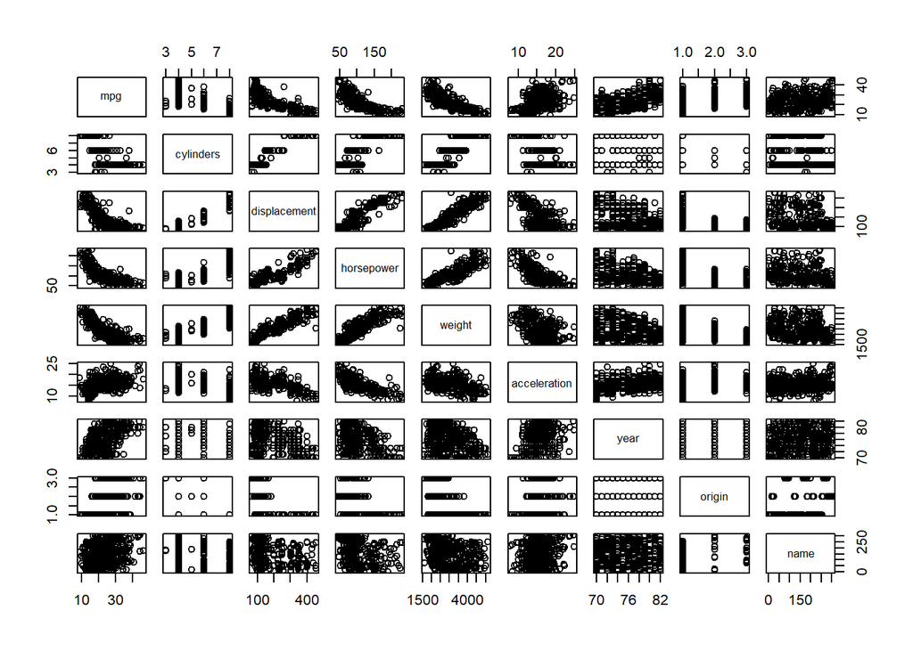

```r
pairs(auto)
```

Right away, there appear to be some strong patterns observed among *displacement*, *horsepower*, *weight*, *year*, and potentially others when plotted against the response, *mpg.* Further, there appears to be some multicollinearity (i.e. strong correlation) between *displacement*, *horsepower*, and *weight*, perhaps accompanied by *acceleration.*

## b)

```r
cor <- round(cor(subset(Auto, select = -name)), 4)
cor   # correlation matrix (rounded for simplicity)
```

```
##                  mpg cylinders displacement horsepower  weight acceleration
## mpg           1.0000   -0.7776      -0.8051    -0.7784 -0.8322       0.4233
## cylinders    -0.7776    1.0000       0.9508     0.8430  0.8975      -0.5047
## displacement -0.8051    0.9508       1.0000     0.8973  0.9330      -0.5438
## horsepower   -0.7784    0.8430       0.8973     1.0000  0.8645      -0.6892
## weight       -0.8322    0.8975       0.9330     0.8645  1.0000      -0.4168
## acceleration  0.4233   -0.5047      -0.5438    -0.6892 -0.4168       1.0000
## year          0.5805   -0.3456      -0.3699    -0.4164 -0.3091       0.2903
## origin        0.5652   -0.5689      -0.6145    -0.4552 -0.5850       0.2127
##                 year  origin
## mpg           0.5805  0.5652
## cylinders    -0.3456 -0.5689
## displacement -0.3699 -0.6145
## horsepower   -0.4164 -0.4552
## weight       -0.3091 -0.5850
## acceleration  0.2903  0.2127
## year          1.0000  0.1815
## origin        0.1815  1.0000
```

There appears to be a strong positive correlation among *cylinders*, *horsepower*, and *weight*, all pairwise. Further, *acceleration* and *horsepower* display a fairly strong negative correlation, as well as the pair of *displacement* and *origin.*

Another way to visualize there correlations:

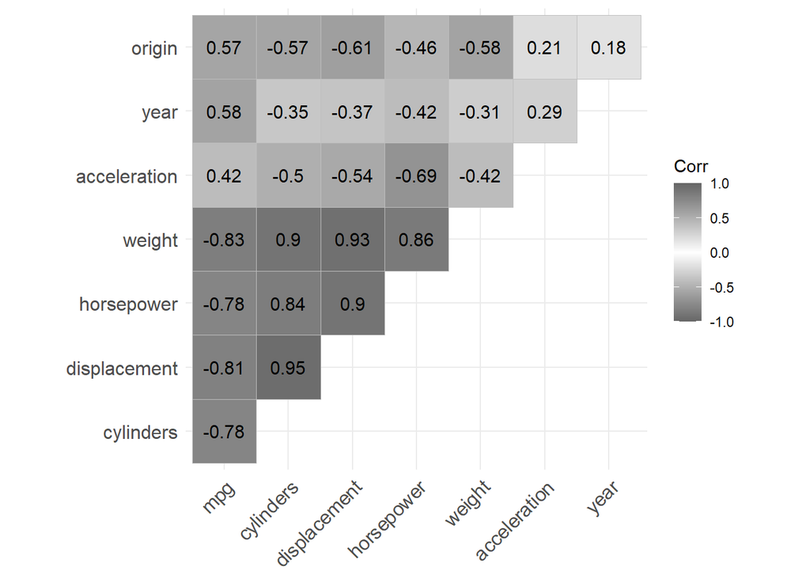

```r
# correlation plot
library(ggcorrplot)
ggcorrplot(cor, lab = TRUE,
           type = "upper",
           colors = c("gray40", "white", "gray40"))
```

## c)

```r
mod1 <- lm(mpg ~ . -name, data = auto)
summary(mod1)
```

```
##
## Call:
## lm(formula = mpg ~ . - name, data = auto)
##
## Residuals:
##     Min      1Q  Median      3Q     Max
## -9.5903 -2.1565 -0.1169  1.8690 13.0604
##
## Coefficients:
##                Estimate Std. Error t value Pr(>|t|)
## (Intercept)  -17.218435   4.644294  -3.707  0.00024 ***
## cylinders     -0.493376   0.323282  -1.526  0.12780
## displacement   0.019896   0.007515   2.647  0.00844 **
## horsepower    -0.016951   0.013787  -1.230  0.21963
## weight        -0.006474   0.000652  -9.929  < 2e-16 ***
## acceleration   0.080576   0.098845   0.815  0.41548
## year           0.750773   0.050973  14.729  < 2e-16 ***
## origin         1.426141   0.278136   5.127 4.67e-07 ***
## ---
## Signif. codes:  0 '***' 0.001 '**' 0.01 '*' 0.05 '.' 0.1 ' ' 1
##
## Residual standard error: 3.328 on 384 degrees of freedom
## Multiple R-squared:  0.8215, Adjusted R-squared:  0.8182
## F-statistic: 252.4 on 7 and 384 DF,  p-value: < 2.2e-16
```

### i)

There is a relationship between the predictors and the response, reflected by the significant p-values associated with variables in the table summary of the model. More specifically, under the model including all potential explanatory variables for *mpg*, *displacement*, *weight*, *year*, and *origin* are statistically significant.

Further, the value of $R^2$ suggests that approximately 82.15% of the variation observed in *mpg* is attributed to the explanatory variables within the model. A low $R^2$ would suggest that the explanatory variables do a poor job in fitting the data of the response variable.

An F-test can be conducted to determine whether this **full** model, that is, one with explanatory variables, performs better than a **reduced** model with a simple (average) coefficient term describing *mpg.* The following are test results:

Let $H_0:$ conclude the reduced model and $H_a:$ conclude the full model.

```r
full <- mod1
reduced <- lm(mpg ~ 1, data = auto)
anova(reduced, full)
```

```
## Analysis of Variance Table
##
## Model 1: mpg ~ 1
## Model 2: mpg ~ (cylinders + displacement + horsepower + weight + acceleration +
##     year + origin + name) - name
##   Res.Df     RSS Df Sum of Sq      F    Pr(>F)
## 1    391 23819.0
## 2    384  4252.2  7     19567 252.43 < 2.2e-16 ***
## ---
## Signif. codes:  0 '***' 0.001 '**' 0.01 '*' 0.05 '.' 0.1 ' ' 1
```

Here, $F = 252.43$ and $p = 2.2 \times 10^{-16} << 0$. Therefore, Reject the null hypothesis and conclude the full model. In other words, the model with explanatory variables is better at predicting the *mpg.*

### ii)

Based on the summary, it appears that there are strong relationships between the response, *mpg*, and *displacement*, *weight*, *year*, and *origin.* The other potential explanatory variables, i.e. *cylinders*, *horsepower*, and *acceleration*, display higher p-values when all variables are included in the model, suggesting that some (if not, all) can be dropped after further testing. It is important to note that some of these variables displayed strong correlations with one another, so testing different models would provide a clearer picture of which variables to include/exclude.

### iii)

The coefficient of the *year* variable suggests that with every single year increase, the response increases by approximately 0.7508 *mpg*. Note that this coefficient could change when considering a model with less variables.

## d)

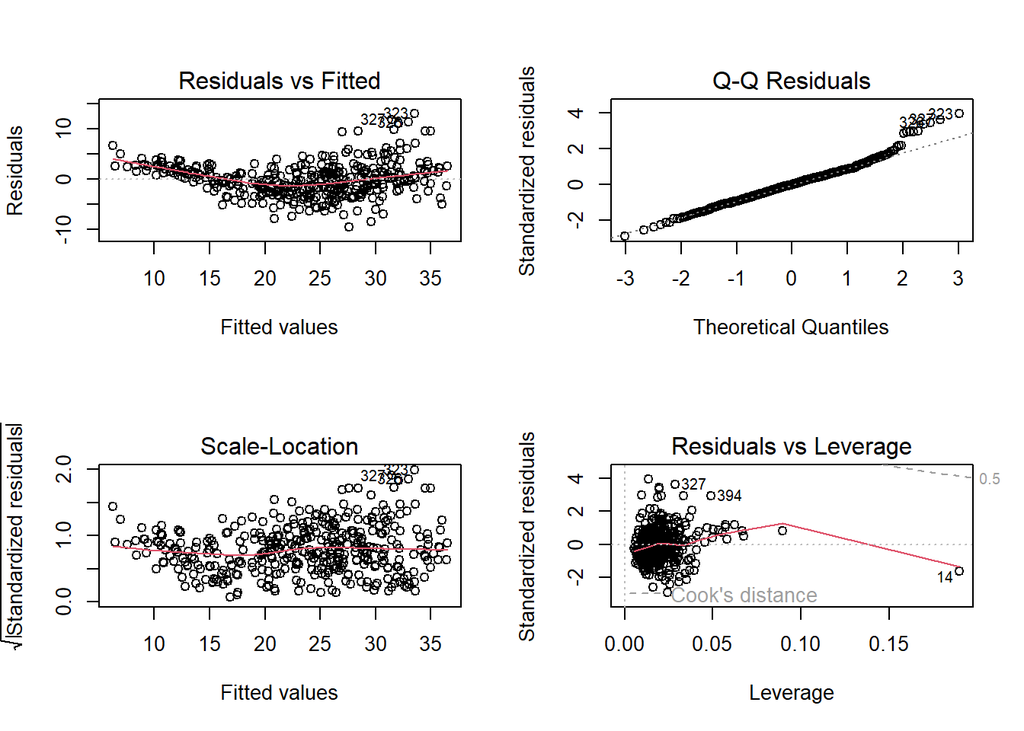

```r
par(mfrow = c(2, 2))
plot(mod1)
```

The plot of the model residuals versus the fitted values displays concern for the constant variance of errors and the assumption of a linear model. Further, this suggests an abnormal distribution of errors. Therefore, a transformation to the response variable, *mpg*, should be tested. Points 323, 326, and 327 appear unusual, displaying high residual values. Overall, it is not the most problematic looking plot, but it likely could use transformations to the original model to minimize these problems with the model assumptions.

The QQ-Plot has some data tailing off from the normal QQ-Line in the top right. This could suggest skewness in the data and the potential for outliers. Once again, points 323, 326, and 327 appear unusual.

The Scale-Location plot displays a mild violation of the constant variance of errors assumption, due to the slightly larger concentration of points on the right with higher residuals than the rest. It appears to slightly fan out, as well, similar to the plot of residuals vs. fitted. Points 323, 326, and 327 exhibit, again, unusual patterns of residuals. Perhaps they are outliers or influential points.

Here are some further testing measures to point out potential outliers and leveraged data points:

```r
n <- nrow(auto)      # sample size
p <- ncol(auto) - 1  # number of predictor variables in model 1

# Finding outliers:
stud.res.test <- function(model, alpha) {
  unique(which(
  abs(rstudent(model)) >= qt(1-alpha/2, n - p - 2)
))
}
stud.res.test(mod1, 0.05)  # all flagged points at alpha level = 0.05
```

```
##  [1]  44 108 111 154 165 243 246 269 308 321 323 324 325 326 328 332 382 389
```

```r
# Bonferroni method:
stud.res.test(mod1, 0.05/(2*n))  # no flagged outliers using Bonferroni adjustment
```

```
## integer(0)
```

Under a less conservative significance level, there are 18 points flagged as potential outliers, whereas using the more conservative Bonferroni adjustment, there are none.

```r
# Finding leverage / influential points:
leverage <- function(model){
  unique(which(
    hatvalues(model) > 2*(p+1)/n
  ))
}
lev.vals <- leverage(mod1)
lev.vals   # flagged leverage values
```

```
##  [1]   7   8   9  14  26  27  28  29  95 116 298 299 360 389
```

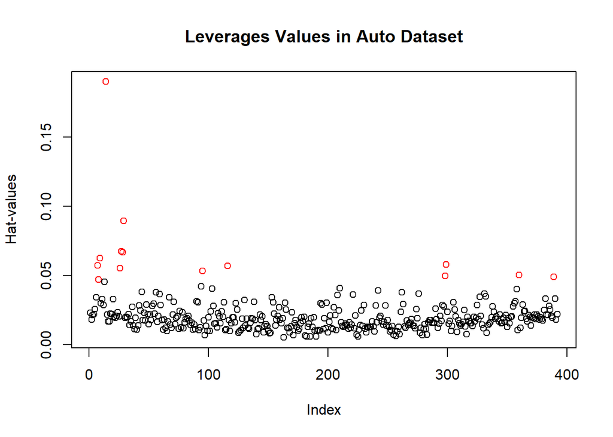

```r
# Plotting the results:
color.vec <- rep("black", length(hatvalues(mod1)))
color.vec[lev.vals] <- "red"

plot(hatvalues(mod1), col = color.vec,
     main = "Leverages Values in Auto Dataset",
     ylab = "Hat-values")
```

Under the criterion using hat-values to find leveraged values and influential points, 14 values were flagged with abnormally high leverage.

## e)

```r
mod2 <- lm(mpg ~ displacement + weight + year + origin + horsepower
           + horsepower:displacement,
           data = auto)
summary(mod2)
```

```
##
## Call:
## lm(formula = mpg ~ displacement + weight + year + origin + horsepower +
##     horsepower:displacement, data = auto)
##
## Residuals:
##     Min      1Q  Median      3Q     Max
## -8.7264 -1.7408 -0.1554  1.4346 11.8969
##
## Coefficients:
##                           Estimate Std. Error t value Pr(>|t|)
## (Intercept)             -6.248e+00  3.769e+00  -1.658  0.09823 .
## displacement            -5.331e-02  7.853e-03  -6.788 4.30e-11 ***
## weight                  -4.013e-03  5.477e-04  -7.328 1.39e-12 ***
## year                     7.457e-01  4.491e-02  16.604  < 2e-16 ***
## origin                   8.221e-01  2.504e-01   3.283  0.00112 **
## horsepower              -1.617e-01  1.634e-02  -9.894  < 2e-16 ***
## displacement:horsepower  4.579e-04  4.353e-05  10.520  < 2e-16 ***
## ---
## Signif. codes:  0 '***' 0.001 '**' 0.01 '*' 0.05 '.' 0.1 ' ' 1
##
## Residual standard error: 2.941 on 385 degrees of freedom
## Multiple R-squared:  0.8602, Adjusted R-squared:  0.858
## F-statistic: 394.8 on 6 and 385 DF,  p-value: < 2.2e-16
```

## f)

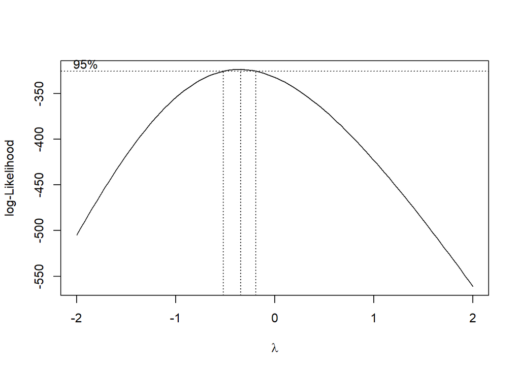

```r
boxcox(mod1)
```

```r
auto$new.mpg <- sqrt(auto$mpg)

mod3 <- lm(new.mpg ~ . -mpg-name, data = auto)
summary(mod3)
```

```
##
## Call:
## lm(formula = new.mpg ~ . - mpg - name, data = auto)
##
## Residuals:
##      Min       1Q   Median       3Q      Max
## -0.98891 -0.18946  0.00505  0.16947  1.02581
##
## Coefficients:
##                Estimate Std. Error t value Pr(>|t|)
## (Intercept)   1.075e+00  4.290e-01   2.506   0.0126 *
## cylinders    -5.942e-02  2.986e-02  -1.990   0.0474 *
## displacement  1.752e-03  6.942e-04   2.524   0.0120 *
## horsepower   -2.512e-03  1.274e-03  -1.972   0.0493 *
## weight       -6.367e-04  6.024e-05 -10.570  < 2e-16 ***
## acceleration  2.738e-03  9.131e-03   0.300   0.7644
## year          7.381e-02  4.709e-03  15.675  < 2e-16 ***
## origin        1.217e-01  2.569e-02   4.735 3.09e-06 ***
## ---
## Signif. codes:  0 '***' 0.001 '**' 0.01 '*' 0.05 '.' 0.1 ' ' 1
##
## Residual standard error: 0.3074 on 384 degrees of freedom
## Multiple R-squared:  0.8561, Adjusted R-squared:  0.8535
## F-statistic: 326.3 on 7 and 384 DF,  p-value: < 2.2e-16
```

```r
mod4 <- lm(new.mpg ~ cylinders + log(displacement) + log(horsepower) +
             log(weight) + acceleration + year + origin, data = auto)
summary(mod4)
```

```
##
## Call:
## lm(formula = new.mpg ~ cylinders + log(displacement) + log(horsepower) +
##     log(weight) + acceleration + year + origin, data = auto)
##
## Residuals:
##      Min       1Q   Median       3Q      Max
## -0.98033 -0.16427 -0.01022  0.15266  1.03773
##
## Coefficients:
##                    Estimate Std. Error t value Pr(>|t|)
## (Intercept)       13.826816   0.946114  14.614  < 2e-16 ***
## cylinders          0.005869   0.026620   0.220  0.82563
## log(displacement) -0.071752   0.132478  -0.542  0.58840
## log(horsepower)   -0.587390   0.145739  -4.030 6.71e-05 ***
## log(weight)       -1.425817   0.204366  -6.977 1.33e-11 ***
## acceleration      -0.019796   0.009561  -2.070  0.03908 *
## year               0.072729   0.004384  16.588  < 2e-16 ***
## origin             0.069286   0.026064   2.658  0.00818 **
## ---
## Signif. codes:  0 '***' 0.001 '**' 0.01 '*' 0.05 '.' 0.1 ' ' 1
##
## Residual standard error: 0.2865 on 384 degrees of freedom
## Multiple R-squared:  0.875,  Adjusted R-squared:  0.8728
## F-statistic: 384.1 on 7 and 384 DF,  p-value: < 2.2e-16
```

Note that significance values changed for the variables under these adjustments, with some losing and some gaining significance depending on the model. Overall, it appears that some transformations could benefit the model fit, but I would advise against getting too crazy with it.

# 10

## a)

```r
mod1 <- lm(Sales ~ Price + Urban + US, data = carseats)
summary(mod1)
```

```
##
## Call:
## lm(formula = Sales ~ Price + Urban + US, data = carseats)
##
## Residuals:
##     Min      1Q  Median      3Q     Max
## -6.9206 -1.6220 -0.0564  1.5786  7.0581
##
## Coefficients:
##              Estimate Std. Error t value Pr(>|t|)
## (Intercept) 13.043469   0.651012  20.036  < 2e-16 ***
## Price       -0.054459   0.005242 -10.389  < 2e-16 ***
## UrbanYes    -0.021916   0.271650  -0.081    0.936
## USYes        1.200573   0.259042   4.635 4.86e-06 ***
## ---
## Signif. codes:  0 '***' 0.001 '**' 0.01 '*' 0.05 '.' 0.1 ' ' 1
##
## Residual standard error: 2.472 on 396 degrees of freedom
## Multiple R-squared:  0.2393, Adjusted R-squared:  0.2335
## F-statistic: 41.52 on 3 and 396 DF,  p-value: < 2.2e-16
```

## b)

```r
# Checking for qualitative variables
is.factor(carseats$Urban) # T
```

```
## [1] TRUE
```

```r
is.factor(carseats$US)    # T
```

```
## [1] TRUE
```

```r
is.factor(carseats$Price) # F
```

```
## [1] FALSE
```

The intercept coefficient of the model (i.e. ~13.04) serves no useful interpretation because it is associated with $0 for *Price*, which is unreasonable, in addition to the specific circumstance of a rural location outside of the US.

The model coefficient attached to the variable *Price* suggests a strong linear relationship such that as price increases by $1, the *Sales* for car seats decrease by approximately 54 units, on average with all other variables held constant.

The model suggests a weak relationship between the urban/rural location of the store (i.e. *Urban*) and *Sales*, as reflected by the p-value close to 1. On average, urban stores sell around 22 units less than rural stores, holding all other variables constant.

There appears to be a strong relationship between the national location of the store (i.e. *US*) and Sales, associated with a p-value near zero. That is, stores located within the US sell approximately 1201 units more than elsewhere, all other variables held constant.

## c)

$\hat Y = 13.04345 - 0.0545X_1 - 0.0219X_2 + 1.2006X_3$ where $Y$ is the unit sales (in thousands) at each location (i.e. *Sales*), $X_1$ is the price the company charges for car seats (i.e. *Price*), $X_2$ indicates whether the store is an urban (Yes ~ 1) or rural (No ~ 0) location (i.e. *Urban*), and $X_3$ indicates whether the store is in the US (Yes ~ 1) or not (No ~ 0) (i.e. *US*).

## d)

According to the model summary, you can reject $H_0: {\beta}_j = 0$ for the *Price* and *US* variables, since they display p-values close to zero, whereas the *Urban* variable displays a high p-value. Therefore, accept the null hypothesis when testing the coefficient associated with *Urban* only.

## e)

```r
mod2 <- lm(Sales ~ Price + US, data = carseats)
summary(mod2)
```

```
##
## Call:
## lm(formula = Sales ~ Price + US, data = carseats)
##
## Residuals:
##     Min      1Q  Median      3Q     Max
## -6.9269 -1.6286 -0.0574  1.5766  7.0515
##
## Coefficients:
##             Estimate Std. Error t value Pr(>|t|)
## (Intercept) 13.03079    0.63098  20.652  < 2e-16 ***
## Price       -0.05448    0.00523 -10.416  < 2e-16 ***
## USYes        1.19964    0.25846   4.641 4.71e-06 ***
## ---
## Signif. codes:  0 '***' 0.001 '**' 0.01 '*' 0.05 '.' 0.1 ' ' 1
##
## Residual standard error: 2.469 on 397 degrees of freedom
## Multiple R-squared:  0.2393, Adjusted R-squared:  0.2354
## F-statistic: 62.43 on 2 and 397 DF,  p-value: < 2.2e-16
```

## f)

When comparing models 1 and 2, there is no noticeable change to the value of $R^2$, which is still approximately 0.2393. However, this second model displays significant contributions by all of its coefficients, unlike model 1. Also, the estimated coefficients changed marginally. Therefore, removing the *Urban* variable preserved the coefficient of determination and did little to affect the remaining variables.

## g)

```r
round(confint(mod2), 4) # default is 95%
```

```
##               2.5 %  97.5 %
## (Intercept) 11.7903 14.2713
## Price       -0.0648 -0.0442
## USYes        0.6915  1.7078
```

An example of an interpretation is that with 95% confidence, the true decrease in unit *Sales* as price goes up by $1 is between approximately 44 and 65 less units sold.

## h)

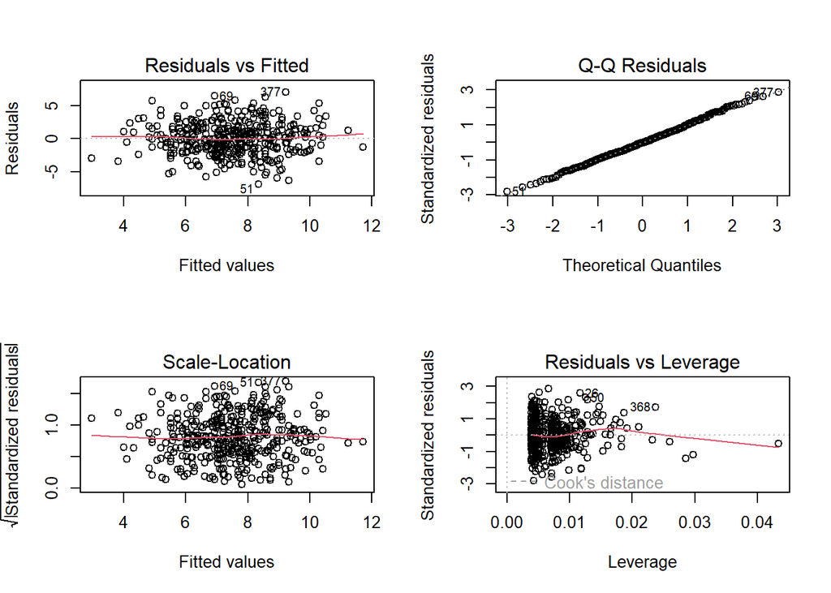

```r
par(mfrow = c(2, 2))
plot(mod2)
```

According to the diagnostic plots, there are quite a few points that suggest evidence for outliers, such as at points 51, 69, and 377 on the first 3 plots, with the additions of points 26, 50, and 368 on the plot of Residuals vs. Leverage. Further testing should be conducted to know for sure which, if any, points are outliers or high leverage observations.

Once again, we can test for potential outliers and leveraged / influential points (proceeding with model 2):

```r
n <- nrow(carseats)  # sample size
p <- 2               # number of predictor variables in model 2

# Finding outliers:
stud.res.test(mod2, 0.05)  # all flagged points at alpha level = 0.05
```

```
##  [1]  18  26  29  31  45  50  51  58  63  69  83  99 107 144 210 259 298 299 305
## [20] 317 329 353 377 396
```

```r
# Bonferroni method:
stud.res.test(mod2, 0.05/(2*n))  # no flagged outliers using Bonferroni adjustment
```

```
## integer(0)
```

There are 24 flagged outlier points using a less conservative significance level, yet none with the Bonferroni adjustment.

```r
# Finding leverage / influential points:
lev.vals <- leverage(mod2)
lev.vals   # flagged leverage values
```

```
##  [1]  43 126 156 157 160 166 172 175 192 204 209 270 273 314 316 357 366 368 384
## [20] 387
```

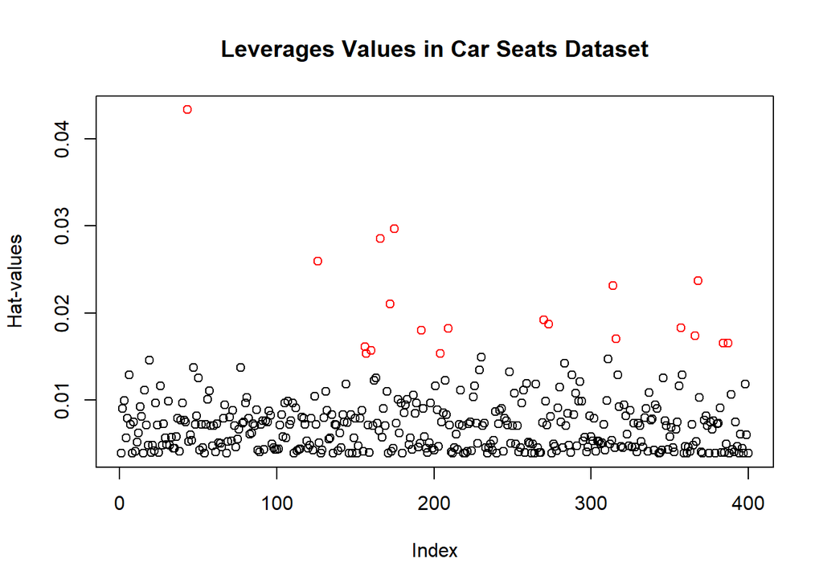

```r
# Plotting the results:
color.vec <- rep("black", length(hatvalues(mod2)))
color.vec[lev.vals] <- "red"

plot(hatvalues(mod2), col = color.vec,
     main = "Leverages Values in Car Seats Dataset",
     ylab = "Hat-values")
```

There are 20 flagged points with unusual leverage under the hat-values procedure, as highlighted in the plot.

# Step-wise Selection (not in book)

## 1

```r
mod1 <- lm(Sales ~ 1, data = carseats)  # no predictor model
mod2 <- lm(Sales ~ . , data = carseats) # model with all predictors
stepAIC(mod2, direction = "backward",
        scope = list(lower=mod1, upper=mod2)) # AIC backwards selection
```

```
## Start:  AIC=26.82
## Sales ~ CompPrice + Income + Advertising + Population + Price +
##     ShelveLoc + Age + Education + Urban + US
##
##               Df Sum of Sq     RSS    AIC
## - Population   1      0.33  403.16  25.15
## - Education    1      1.19  404.02  26.00
## - Urban        1      1.23  404.06  26.04
## - US           1      1.57  404.40  26.38
## <none>                      402.83  26.82
## - Income       1     76.16  478.99  94.09
## - Advertising  1    127.14  529.97 134.54
## - Age          1    217.44  620.27 197.48
## - CompPrice    1    519.91  922.74 356.35
## - ShelveLoc    2   1053.20 1456.03 536.80
## - Price        1   1323.23 1726.06 606.85
##
## Step:  AIC=25.15
## Sales ~ CompPrice + Income + Advertising + Price + ShelveLoc +
##     Age + Education + Urban + US
##
##               Df Sum of Sq     RSS    AIC
## - Urban        1      1.15  404.31  24.29
## - Education    1      1.36  404.52  24.49
## - US           1      1.89  405.05  25.02
## <none>                      403.16  25.15
## - Income       1     75.94  479.10  92.18
## - Advertising  1    145.38  548.54 146.32
## - Age          1    218.52  621.68 196.38
## - CompPrice    1    521.69  924.85 355.27
## - ShelveLoc    2   1053.18 1456.34 534.89
## - Price        1   1323.51 1726.67 605.00
##
## Step:  AIC=24.29
## Sales ~ CompPrice + Income + Advertising + Price + ShelveLoc +
##     Age + Education + US
##
##               Df Sum of Sq     RSS    AIC
## - Education    1      1.44  405.76  23.72
## - US           1      1.85  406.16  24.12
```

[output cut: 19 more lines]

```
## - ShelveLoc    2   1056.88 1462.64 532.61
## - Price        1   1322.83 1728.58 601.44
##
## Step:  AIC=23.32
## Sales ~ CompPrice + Income + Advertising + Price + ShelveLoc +
##     Age
##
##               Df Sum of Sq     RSS    AIC
## <none>                      407.39  23.32
## - Income       1     76.68  484.07  90.30
## - Age          1    219.12  626.51 193.48
## - Advertising  1    234.03  641.42 202.89
## - CompPrice    1    523.83  931.22 352.01
## - ShelveLoc    2   1055.51 1462.90 530.68
## - Price        1   1324.42 1731.81 600.18
```

```
##
## Call:
## lm(formula = Sales ~ CompPrice + Income + Advertising + Price +
##     ShelveLoc + Age, data = carseats)
##
## Coefficients:
##     (Intercept)        CompPrice           Income      Advertising
##         5.47523          0.09257          0.01578          0.11590
##           Price    ShelveLocGood  ShelveLocMedium              Age
##        -0.09532          4.83567          1.95199         -0.04613
```

The model to predict *Sales* suggested by the AIC criterion using **backwards** selection consists of *CompPrice*, *Income*, *Advertising*, *Price*, *ShelveLoc*, and *Age*. The associated AIC value is 23.32.

## 2

```r
stepAIC(mod1, direction = "forward",
        scope = list(lower=mod1, upper=mod2)) # AIC forwards selection
```

```
## Start:  AIC=831.55
## Sales ~ 1
##
##               Df Sum of Sq    RSS    AIC
## + ShelveLoc    2   1009.53 2172.7 682.91
## + Price        1    630.03 2552.2 745.31
## + Advertising  1    231.14 2951.1 803.39
## + Age          1    171.01 3011.3 811.46
## + US           1     99.80 3082.5 820.81
## + Income       1     73.48 3108.8 824.21
## <none>                     3182.3 831.55
## + CompPrice    1     13.07 3169.2 831.91
## + Education    1      8.59 3173.7 832.47
## + Population   1      8.11 3174.2 832.53
## + Urban        1      0.76 3181.5 833.46
##
## Step:  AIC=682.91
## Sales ~ ShelveLoc
##
##               Df Sum of Sq    RSS    AIC
## + Price        1    717.10 1455.6 524.69
## + Advertising  1    178.35 1994.4 650.65
## + Age          1    175.00 1997.8 651.32
## + Income       1     99.93 2072.8 666.08
## + US           1     66.54 2106.2 672.47
## <none>                     2172.7 682.91
## + Population   1     10.71 2162.0 682.94
## + CompPrice    1      6.00 2166.7 683.81
## + Education    1      4.19 2168.6 684.14
## + Urban        1      1.70 2171.1 684.60
##
## Step:  AIC=524.69
## Sales ~ ShelveLoc + Price
##
##               Df Sum of Sq     RSS    AIC
## + CompPrice    1    496.96  958.68 359.64
## + Age          1    258.05 1197.59 448.64
## + Advertising  1    209.73 1245.91 464.46
## + US           1     93.07 1362.57 500.26
## + Income       1     73.04 1382.60 506.10
```

[output cut: 35 more lines]

```
## + Education   1     2.488 481.58 90.243
## <none>                    484.07 90.304
## + Urban       1     1.975 482.09 90.669
## + US          1     0.443 483.62 91.937
## + Population  1     0.285 483.78 92.069
##
## Step:  AIC=23.32
## Sales ~ ShelveLoc + Price + CompPrice + Advertising + Age + Income
##
##              Df Sum of Sq    RSS    AIC
## <none>                    407.39 23.320
## + US          1   1.62857 405.76 23.717
## + Education   1   1.22240 406.16 24.117
## + Urban       1   1.18994 406.20 24.149
## + Population  1   0.71569 406.67 24.616
```

```
##
## Call:
## lm(formula = Sales ~ ShelveLoc + Price + CompPrice + Advertising +
##     Age + Income, data = carseats)
##
## Coefficients:
##     (Intercept)    ShelveLocGood  ShelveLocMedium            Price
##         5.47523          4.83567          1.95199         -0.09532
##       CompPrice      Advertising              Age           Income
##         0.09257          0.11590         -0.04613          0.01578
```

The suggested model using **forward** selection is the same as the one found using **backward** selection. The only difference is the order in which the variables are listed within the model, although their associated estimated coefficients are the same as in part 1. The AIC value is 23.32, once again.

The model is estimated as follows:

$Sales = 5.48 + 4.84(ShelveLocGood) + 1.95(ShelveLocMedium) - 0.10(Price) + 0.09(CompPrice) + 0.12(Advertising) - 0.05(Age) + 0.02(Income)$

## 3

```r
n <- nrow(carseats)
stepAIC(mod2, direction = "backward",
        scope = list(lower=mod1, upper=mod2),
        k = log(n)) # BIC backwards selection
```

```
## Start:  AIC=74.72
## Sales ~ CompPrice + Income + Advertising + Population + Price +
##     ShelveLoc + Age + Education + Urban + US
##
##               Df Sum of Sq     RSS    AIC
## - Population   1      0.33  403.16  69.05
## - Education    1      1.19  404.02  69.91
## - Urban        1      1.23  404.06  69.95
## - US           1      1.57  404.40  70.28
## <none>                      402.83  74.72
## - Income       1     76.16  478.99 137.99
## - Advertising  1    127.14  529.97 178.45
## - Age          1    217.44  620.27 241.38
## - CompPrice    1    519.91  922.74 400.26
## - ShelveLoc    2   1053.20 1456.03 576.72
## - Price        1   1323.23 1726.06 650.76
##
## Step:  AIC=69.05
## Sales ~ CompPrice + Income + Advertising + Price + ShelveLoc +
##     Age + Education + Urban + US
##
##               Df Sum of Sq     RSS    AIC
## - Urban        1      1.15  404.31  64.21
## - Education    1      1.36  404.52  64.41
## - US           1      1.89  405.05  64.94
## <none>                      403.16  69.05
## - Income       1     75.94  479.10 132.09
## - Advertising  1    145.38  548.54 186.23
## - Age          1    218.52  621.68 236.30
## - CompPrice    1    521.69  924.85 395.18
## - ShelveLoc    2   1053.18 1456.34 570.81
## - Price        1   1323.51 1726.67 644.91
##
## Step:  AIC=64.21
## Sales ~ CompPrice + Income + Advertising + Price + ShelveLoc +
##     Age + Education + US
##
##               Df Sum of Sq     RSS    AIC
## - Education    1      1.44  405.76  59.64
## - US           1      1.85  406.16  60.04
```

[output cut: 19 more lines]

```
## - ShelveLoc    2   1056.88 1462.64 560.55
## - Price        1   1322.83 1728.58 633.37
##
## Step:  AIC=55.25
## Sales ~ CompPrice + Income + Advertising + Price + ShelveLoc +
##     Age
##
##               Df Sum of Sq     RSS    AIC
## <none>                      407.39  55.25
## - Income       1     76.68  484.07 118.24
## - Age          1    219.12  626.51 221.42
## - Advertising  1    234.03  641.42 230.83
## - CompPrice    1    523.83  931.22 379.95
## - ShelveLoc    2   1055.51 1462.90 554.63
## - Price        1   1324.42 1731.81 628.12
```

```
##
## Call:
## lm(formula = Sales ~ CompPrice + Income + Advertising + Price +
##     ShelveLoc + Age, data = carseats)
##
## Coefficients:
##     (Intercept)        CompPrice           Income      Advertising
##         5.47523          0.09257          0.01578          0.11590
##           Price    ShelveLocGood  ShelveLocMedium              Age
##        -0.09532          4.83567          1.95199         -0.04613
```

Using the BIC criterion and *backward* selection, the model for *Sales* is the same suggestion as found with the AIC criterion. Further, the variables are ordered in the same manner that they were for the *backwards* selection using the AIC criterion, found in part 1. The BIC value for the model is 55.25, which is different than the AIC value, due to the difference in criterion method.

## 4

```r
stepAIC(mod1, direction = "forward",
        scope = list(lower=mod1, upper=mod2),
        k = log(n)) # BIC forwards selection
```

```
## Start:  AIC=835.55
## Sales ~ 1
##
##               Df Sum of Sq    RSS    AIC
## + ShelveLoc    2   1009.53 2172.7 694.89
## + Price        1    630.03 2552.2 753.29
## + Advertising  1    231.14 2951.1 811.37
## + Age          1    171.01 3011.3 819.44
## + US           1     99.80 3082.5 828.79
## + Income       1     73.48 3108.8 832.19
## <none>                     3182.3 835.55
## + CompPrice    1     13.07 3169.2 839.89
## + Education    1      8.59 3173.7 840.46
## + Population   1      8.11 3174.2 840.52
## + Urban        1      0.76 3181.5 841.44
##
## Step:  AIC=694.89
## Sales ~ ShelveLoc
##
##               Df Sum of Sq    RSS    AIC
## + Price        1    717.10 1455.6 540.66
## + Advertising  1    178.35 1994.4 666.62
## + Age          1    175.00 1997.8 667.29
## + Income       1     99.93 2072.8 682.05
## + US           1     66.54 2106.2 688.44
## <none>                     2172.7 694.89
## + Population   1     10.71 2162.0 698.90
## + CompPrice    1      6.00 2166.7 699.77
## + Education    1      4.19 2168.6 700.11
## + Urban        1      1.70 2171.1 700.57
##
## Step:  AIC=540.66
## Sales ~ ShelveLoc + Price
##
##               Df Sum of Sq     RSS    AIC
## + CompPrice    1    496.96  958.68 379.59
## + Age          1    258.05 1197.59 468.60
## + Advertising  1    209.73 1245.91 484.42
## + US           1     93.07 1362.57 520.22
## + Income       1     73.04 1382.60 526.06
```

[output cut: 35 more lines]

```
## <none>                    484.07 118.244
## + Education   1     2.488 481.58 122.175
## + Urban       1     1.975 482.09 122.601
## + US          1     0.443 483.62 123.869
## + Population  1     0.285 483.78 124.000
##
## Step:  AIC=55.25
## Sales ~ ShelveLoc + Price + CompPrice + Advertising + Age + Income
##
##              Df Sum of Sq    RSS    AIC
## <none>                    407.39 55.251
## + US          1   1.62857 405.76 59.640
## + Education   1   1.22240 406.16 60.041
## + Urban       1   1.18994 406.20 60.073
## + Population  1   0.71569 406.67 60.539
```

```
##
## Call:
## lm(formula = Sales ~ ShelveLoc + Price + CompPrice + Advertising +
##     Age + Income, data = carseats)
##
## Coefficients:
##     (Intercept)    ShelveLocGood  ShelveLocMedium            Price
##         5.47523          4.83567          1.95199         -0.09532
##       CompPrice      Advertising              Age           Income
##         0.09257          0.11590         -0.04613          0.01578
```

Similar to part 3, the suggested model under the BIC criterion using *forward* selection has the same 6 variables in all of the previous answers. This time, the order of the variables listed follows the same pattern as the *forward* selection of the AIC criterion. Here, the reported BIC value is the same as in part 3, which is 55.25.